# ANCOVA in TDE - Escrita (TDE - Escrita)

Geiser C. Challco geiser@alumni.usp.br

- Descriptive Statistics of Initial Data
- ANCOVA and Pairwise for one factor: **grupo**
  - Without remove non-normal data
  - Computing ANCOVA and PairWise After removing non-normal data (OK)
    - Plots for ancova
    - Checking linearity assumption
    - Checking normality and homogeneity
- ANCOVA and Pairwise for two factors **grupo:Sexo**
  - Without remove non-normal data
  - Computing ANCOVA and PairWise After removing non-normal data (OK)
    - Plots for ancova
    - Checking linearity assumption
    - Checking normality and homogeneity
- ANCOVA and Pairwise for two factors **grupo:Zona**
  - Without remove non-normal data
  - Computing ANCOVA and PairWise After removing non-normal data (OK)
    - Plots for ancova
    - Checking linearity assumption
    - Checking normality and homogeneity
- ANCOVA and Pairwise for two factors **grupo:Cor.Raca**
  - Without remove non-normal data
  - Computing ANCOVA and PairWise After removing non-normal data (OK)
    - Plots for ancova
    - Checking linearity assumption
    - Checking normality and homogeneity
- ANCOVA and Pairwise for two factors **grupo:score.tde.quintile**
  - Without remove non-normal data
  - Computing ANCOVA and PairWise After removing non-normal data (OK)
    - Plots for ancova
    - Checking linearity assumption
    - Checking normality and homogeneity
- Summary of Results
  - Descriptive Statistics
  - ANCOVA Table Comparison
  - PairWise Table Comparison
  - EMMS Table Comparison

**NOTE**:

- Teste ANCOVA para determinar se houve diferenças significativas no TDE - Escrita (medido usando pre- e pos-testes).
- ANCOVA test to determine whether there were significant differences in TDE - Escrita (measured using pre- and post-tests).

# Descriptive Statistics of Initial Data

```r
df <- get.descriptives(dat, c(dv.pre, dv.pos), c("grupo"),
                       include.global = T, symmetry.test = T, normality.test = F)
df <- plyr::rbind.fill(
  df, do.call(plyr::rbind.fill, lapply(lfatores2, FUN = function(f) {
    if (nrow(dat) > 0 && sum(!is.na(unique(dat[[f]]))) > 1)
      get.descriptives(dat, c(dv.pre,dv.pos), c("grupo", f),
                       symmetry.test = T, normality.test = F)
    }))
)
(df <- df[,c(fatores1[fatores1 %in% colnames(df)],"variable",
             colnames(df)[!colnames(df) %in% c(fatores1,"variable")])])
```

```
##           grupo Sexo   Zona Cor.Raca score.tde.quintile      variable   n   mean median min max     sd    se
## 1      Controle <NA>   <NA>     <NA>               <NA> score.tde.pre  89 42.584   46.0   0  72 16.382 1.737
## 2  Experimental <NA>   <NA>     <NA>               <NA> score.tde.pre 143 39.000   44.0   0  73 18.129 1.516
## 3          <NA> <NA>   <NA>     <NA>               <NA> score.tde.pre 232 40.375   44.0   0  73 17.530 1.151
## 4      Controle <NA>   <NA>     <NA>               <NA> score.tde.pos  89 39.787   43.0   0  71 17.900 1.897
## 5  Experimental <NA>   <NA>     <NA>               <NA> score.tde.pos 143 41.042   45.0   0  73 19.177 1.604
## 6          <NA> <NA>   <NA>     <NA>               <NA> score.tde.pos 232 40.560   44.5   0  73 18.668 1.226
## 7      Controle    F   <NA>     <NA>               <NA> score.tde.pre  48 45.771   49.0   3  72 15.134 2.184
## 8      Controle    M   <NA>     <NA>               <NA> score.tde.pre  41 38.854   43.0   0  68 17.172 2.682
## 9  Experimental    F   <NA>     <NA>               <NA> score.tde.pre  73 42.164   47.0   0  73 19.170 2.244
## 10 Experimental    M   <NA>     <NA>               <NA> score.tde.pre  70 35.700   39.0   0  69 16.470 1.969
## 11     Controle    F   <NA>     <NA>               <NA> score.tde.pos  48 43.688   48.0   0  71 16.869 2.435
## 12     Controle    M   <NA>     <NA>               <NA> score.tde.pos  41 35.220   34.0   0  69 18.191 2.841
## 13 Experimental    F   <NA>     <NA>               <NA> score.tde.pos  73 45.589   51.0   0  73 19.811 2.319
## 14 Experimental    M   <NA>     <NA>               <NA> score.tde.pos  70 36.300   39.5   0  69 17.395 2.079
```

[output cut: 98 more lines]

| grupo | Sexo | Zona | Cor.Raca | score.tde.quintile | variable | n | mean | median | min | max | sd | se | ci | iqr | symmetry | skewness | kurtosis |
| --- | --- | --- | --- | --- | --- | --- | --- | --- | --- | --- | --- | --- | --- | --- | --- | --- | --- |
| Controle |  |  |  |  | score.tde.pre | 89 | 42.584 | 46.0 | 0 | 72 | 16.382 | 1.737 | 3.451 | 17.00 | NO | -0.833 | 0.214 |
| Experimental |  |  |  |  | score.tde.pre | 143 | 39.000 | 44.0 | 0 | 73 | 18.129 | 1.516 | 2.997 | 25.50 | NO | -0.515 | -0.734 |
|  |  |  |  |  | score.tde.pre | 232 | 40.375 | 44.0 | 0 | 73 | 17.530 | 1.151 | 2.268 | 23.25 | NO | -0.640 | -0.428 |
| Controle |  |  |  |  | score.tde.pos | 89 | 39.787 | 43.0 | 0 | 71 | 17.900 | 1.897 | 3.771 | 28.00 | NO | -0.521 | -0.552 |
| Experimental |  |  |  |  | score.tde.pos | 143 | 41.042 | 45.0 | 0 | 73 | 19.177 | 1.604 | 3.170 | 26.50 | NO | -0.568 | -0.652 |
|  |  |  |  |  | score.tde.pos | 232 | 40.560 | 44.5 | 0 | 73 | 18.668 | 1.226 | 2.415 | 28.25 | NO | -0.549 | -0.598 |
| Controle | F |  |  |  | score.tde.pre | 48 | 45.771 | 49.0 | 3 | 72 | 15.134 | 2.184 | 4.394 | 17.00 | NO | -0.763 | 0.276 |
| Controle | M |  |  |  | score.tde.pre | 41 | 38.854 | 43.0 | 0 | 68 | 17.172 | 2.682 | 5.420 | 23.00 | NO | -0.816 | -0.253 |
| Experimental | F |  |  |  | score.tde.pre | 73 | 42.164 | 47.0 | 0 | 73 | 19.170 | 2.244 | 4.473 | 26.00 | NO | -0.689 | -0.697 |
| Experimental | M |  |  |  | score.tde.pre | 70 | 35.700 | 39.0 | 0 | 69 | 16.470 | 1.969 | 3.927 | 23.25 | YES | -0.481 | -0.675 |
| Controle | F |  |  |  | score.tde.pos | 48 | 43.688 | 48.0 | 0 | 71 | 16.869 | 2.435 | 4.898 | 27.50 | NO | -0.654 | -0.508 |
| Controle | M |  |  |  | score.tde.pos | 41 | 35.220 | 34.0 | 0 | 69 | 18.191 | 2.841 | 5.742 | 25.00 | YES | -0.362 | -0.661 |
| Experimental | F |  |  |  | score.tde.pos | 73 | 45.589 | 51.0 | 0 | 73 | 19.811 | 2.319 | 4.622 | 25.00 | NO | -0.824 | -0.442 |
| Experimental | M |  |  |  | score.tde.pos | 70 | 36.300 | 39.5 | 0 | 69 | 17.395 | 2.079 | 4.148 | 24.75 | NO | -0.524 | -0.644 |
| Controle |  | Rural |  |  | score.tde.pre | 32 | 43.906 | 49.0 | 0 | 67 | 17.222 | 3.044 | 6.209 | 12.25 | NO | -1.210 | 0.522 |
| Controle |  | Urbana |  |  | score.tde.pre | 18 | 45.333 | 49.0 | 1 | 72 | 16.464 | 3.881 | 8.187 | 16.75 | NO | -0.773 | 0.669 |
| Controle |  |  |  |  | score.tde.pre | 39 | 40.231 | 42.0 | 0 | 68 | 15.734 | 2.519 | 5.100 | 21.50 | YES | -0.488 | -0.387 |
| Experimental |  | Rural |  |  | score.tde.pre | 54 | 38.519 | 42.5 | 0 | 73 | 18.417 | 2.506 | 5.027 | 24.50 | YES | -0.487 | -0.733 |
| Experimental |  | Urbana |  |  | score.tde.pre | 21 | 44.857 | 46.0 | 5 | 61 | 14.914 | 3.255 | 6.789 | 12.00 | NO | -1.451 | 1.459 |
| Experimental |  |  |  |  | score.tde.pre | 68 | 37.574 | 43.5 | 0 | 69 | 18.677 | 2.265 | 4.521 | 28.25 | YES | -0.293 | -1.024 |
| Controle |  | Rural |  |  | score.tde.pos | 32 | 41.750 | 48.5 | 0 | 65 | 18.624 | 3.292 | 6.715 | 22.75 | NO | -0.959 | -0.108 |
| Controle |  | Urbana |  |  | score.tde.pos | 18 | 41.722 | 40.0 | 0 | 71 | 17.374 | 4.095 | 8.640 | 24.50 | YES | -0.366 | -0.250 |
| Controle |  |  |  |  | score.tde.pos | 39 | 37.282 | 40.0 | 0 | 69 | 17.680 | 2.831 | 5.731 | 28.00 | YES | -0.170 | -1.065 |
| Experimental |  | Rural |  |  | score.tde.pos | 54 | 39.333 | 42.5 | 0 | 71 | 20.724 | 2.820 | 5.656 | 31.00 | YES | -0.410 | -1.031 |
| Experimental |  | Urbana |  |  | score.tde.pos | 21 | 46.905 | 50.0 | 5 | 64 | 15.165 | 3.309 | 6.903 | 11.00 | NO | -1.374 | 1.263 |
| Experimental |  |  |  |  | score.tde.pos | 68 | 40.588 | 43.0 | 0 | 73 | 18.912 | 2.293 | 4.578 | 25.50 | YES | -0.458 | -0.668 |
| Controle |  |  | Branca |  | score.tde.pre | 4 | 54.750 | 56.0 | 40 | 67 | 11.587 | 5.793 | 18.437 | 12.75 | YES | -0.200 | -2.020 |
| Controle |  |  | Parda |  | score.tde.pre | 34 | 44.353 | 48.0 | 0 | 62 | 14.781 | 2.535 | 5.157 | 10.75 | NO | -1.445 | 1.859 |
| Controle |  |  |  |  | score.tde.pre | 51 | 40.451 | 43.0 | 0 | 72 | 17.364 | 2.431 | 4.884 | 23.00 | YES | -0.485 | -0.470 |
| Experimental |  |  | Amarela |  | score.tde.pre | 1 | 23.000 | 23.0 | 23 | 23 |  |  |  | 0.00 | few data | 0.000 | 0.000 |
| Experimental |  |  | Branca |  | score.tde.pre | 20 | 40.800 | 46.0 | 0 | 73 | 21.100 | 4.718 | 9.875 | 27.00 | NO | -0.506 | -0.804 |
| Experimental |  |  | Parda |  | score.tde.pre | 51 | 36.569 | 39.0 | 2 | 67 | 18.735 | 2.623 | 5.269 | 29.00 | YES | -0.447 | -1.160 |
| Experimental |  |  |  |  | score.tde.pre | 71 | 40.465 | 44.0 | 0 | 69 | 16.854 | 2.000 | 3.989 | 21.50 | NO | -0.572 | -0.558 |
| Controle |  |  | Branca |  | score.tde.pos | 4 | 51.250 | 50.5 | 39 | 65 | 11.558 | 5.779 | 18.391 | 14.75 | YES | 0.101 | -2.155 |
| Controle |  |  | Parda |  | score.tde.pos | 34 | 41.324 | 48.0 | 0 | 65 | 18.270 | 3.133 | 6.375 | 25.75 | NO | -0.803 | -0.470 |
| Controle |  |  |  |  | score.tde.pos | 51 | 37.863 | 38.0 | 0 | 71 | 17.881 | 2.504 | 5.029 | 26.50 | YES | -0.268 | -0.655 |
| Experimental |  |  | Amarela |  | score.tde.pos | 1 | 23.000 | 23.0 | 23 | 23 |  |  |  | 0.00 | few data | 0.000 | 0.000 |
| Experimental |  |  | Branca |  | score.tde.pos | 20 | 38.450 | 49.0 | 0 | 71 | 23.909 | 5.346 | 11.190 | 34.50 | YES | -0.438 | -1.338 |
| Experimental |  |  | Parda |  | score.tde.pos | 51 | 39.098 | 45.0 | 0 | 70 | 19.499 | 2.730 | 5.484 | 26.00 | YES | -0.453 | -0.947 |
| Experimental |  |  |  |  | score.tde.pos | 71 | 43.423 | 47.0 | 0 | 73 | 17.441 | 2.070 | 4.128 | 20.50 | NO | -0.618 | -0.360 |
| Controle |  |  |  | 1st quintile | score.tde.pre | 10 | 8.800 | 10.0 | 0 | 18 | 7.223 | 2.284 | 5.167 | 13.25 | YES | -0.085 | -1.871 |
| Controle |  |  |  | 2nd quintile | score.tde.pre | 10 | 26.500 | 27.0 | 19 | 31 | 4.143 | 1.310 | 2.964 | 3.50 | NO | -0.658 | -0.990 |
| Controle |  |  |  | 3rd quintile | score.tde.pre | 17 | 38.824 | 39.0 | 34 | 42 | 2.811 | 0.682 | 1.446 | 5.00 | YES | -0.291 | -1.338 |
| Controle |  |  |  | 4th quintile | score.tde.pre | 24 | 47.542 | 48.0 | 43 | 51 | 2.734 | 0.558 | 1.155 | 5.00 | YES | -0.441 | -1.340 |
| Controle |  |  |  | 5th quintile | score.tde.pre | 28 | 58.429 | 57.5 | 52 | 72 | 5.561 | 1.051 | 2.156 | 7.25 | NO | 0.651 | -0.577 |
| Experimental |  |  |  | 1st quintile | score.tde.pre | 27 | 9.037 | 10.0 | 0 | 16 | 5.034 | 0.969 | 1.992 | 8.00 | YES | -0.260 | -1.313 |
| Experimental |  |  |  | 2nd quintile | score.tde.pre | 19 | 27.105 | 27.0 | 22 | 31 | 3.107 | 0.713 | 1.498 | 5.00 | YES | -0.282 | -1.474 |
| Experimental |  |  |  | 3rd quintile | score.tde.pre | 19 | 37.158 | 38.0 | 32 | 42 | 2.892 | 0.663 | 1.394 | 4.00 | YES | -0.175 | -1.348 |
| Experimental |  |  |  | 4th quintile | score.tde.pre | 37 | 46.703 | 46.0 | 43 | 51 | 2.644 | 0.435 | 0.882 | 5.00 | YES | 0.366 | -1.203 |
| Experimental |  |  |  | 5th quintile | score.tde.pre | 41 | 58.146 | 57.0 | 52 | 73 | 5.512 | 0.861 | 1.740 | 6.00 | NO | 0.924 | -0.002 |
| Controle |  |  |  | 1st quintile | score.tde.pos | 10 | 7.100 | 3.0 | 0 | 21 | 8.774 | 2.775 | 6.277 | 14.00 | NO | 0.555 | -1.583 |
| Controle |  |  |  | 2nd quintile | score.tde.pos | 10 | 22.800 | 25.0 | 15 | 27 | 4.417 | 1.397 | 3.160 | 5.50 | NO | -0.778 | -1.255 |
| Controle |  |  |  | 3rd quintile | score.tde.pos | 17 | 36.529 | 36.0 | 19 | 59 | 12.047 | 2.922 | 6.194 | 14.00 | YES | 0.472 | -0.882 |
| Controle |  |  |  | 4th quintile | score.tde.pos | 24 | 44.958 | 47.0 | 28 | 55 | 8.917 | 1.820 | 3.765 | 13.00 | NO | -0.551 | -1.100 |
| Controle |  |  |  | 5th quintile | score.tde.pos | 28 | 55.071 | 56.0 | 32 | 71 | 9.116 | 1.723 | 3.535 | 9.25 | YES | -0.460 | -0.277 |
| Experimental |  |  |  | 1st quintile | score.tde.pos | 27 | 12.074 | 10.0 | 0 | 51 | 10.820 | 2.082 | 4.280 | 12.50 | NO | 1.613 | 3.658 |
| Experimental |  |  |  | 2nd quintile | score.tde.pos | 19 | 28.053 | 29.0 | 1 | 46 | 11.301 | 2.593 | 5.447 | 11.50 | YES | -0.498 | -0.229 |
| Experimental |  |  |  | 3rd quintile | score.tde.pos | 19 | 44.789 | 43.0 | 24 | 64 | 9.790 | 2.246 | 4.719 | 11.50 | YES | 0.050 | -0.522 |
| Experimental |  |  |  | 4th quintile | score.tde.pos | 37 | 47.405 | 47.0 | 35 | 64 | 7.533 | 1.238 | 2.512 | 9.00 | YES | 0.372 | -0.656 |
| Experimental |  |  |  | 5th quintile | score.tde.pos | 41 | 58.659 | 59.0 | 39 | 73 | 8.302 | 1.297 | 2.621 | 13.00 | YES | -0.336 | -0.655 |

# ANCOVA and Pairwise for one factor: **grupo**

## Without remove non-normal data

```r
pdat = remove_group_data(dat[!is.na(dat[["grupo"]]),], "score.tde.pos", "grupo")

pdat.long <- rbind(pdat[,c("id","grupo")], pdat[,c("id","grupo")])
pdat.long[["time"]] <- c(rep("pre", nrow(pdat)), rep("pos", nrow(pdat)))
pdat.long[["time"]] <- factor(pdat.long[["time"]], c("pre","pos"))
pdat.long[["score.tde"]] <- c(pdat[["score.tde.pre"]], pdat[["score.tde.pos"]])

aov = anova_test(pdat, score.tde.pos ~ score.tde.pre + grupo)
laov[["grupo"]] <- get_anova_table(aov)
```

```r
pwc <- emmeans_test(pdat, score.tde.pos ~ grupo, covariate = score.tde.pre,
                    p.adjust.method = "bonferroni")
```

```r
pwc.long <- emmeans_test(dplyr::group_by_at(pdat.long, "grupo"),
                          score.tde ~ time,
                          p.adjust.method = "bonferroni")
lpwc[["grupo"]] <- plyr::rbind.fill(pwc, pwc.long)
```

```r
ds <- get.descriptives(pdat, "score.tde.pos", "grupo", covar = "score.tde.pre")
ds <- merge(ds[ds$variable != "score.tde.pre",],
            ds[ds$variable == "score.tde.pre", !colnames(ds) %in% c("variable")],
            by = "grupo", all.x = T, suffixes = c("", ".score.tde.pre"))
ds <- merge(get_emmeans(pwc), ds, by = "grupo", suffixes = c(".emms", ""))
ds <- ds[,c("grupo","n","mean.score.tde.pre","se.score.tde.pre","mean","se","emmean","se.emms")]

colnames(ds) <- c("grupo", "N", paste0(c("M","SE")," (pre)"),
                  paste0(c("M","SE"), " (unadj)"), paste0(c("M", "SE"), " (adj)"))

lemms[["grupo"]] <- ds
```

## Computing ANCOVA and PairWise After removing non-normal data (OK)

```r
wdat = pdat

res = residuals(lm(score.tde.pos ~ score.tde.pre + grupo, data = wdat))
non.normal = getNonNormal(res, wdat$id, plimit = 0.05)

wdat = wdat[!wdat$id %in% non.normal,]

wdat.long <- rbind(wdat[,c("id","grupo")], wdat[,c("id","grupo")])
wdat.long[["time"]] <- c(rep("pre", nrow(wdat)), rep("pos", nrow(wdat)))
wdat.long[["time"]] <- factor(wdat.long[["time"]], c("pre","pos"))
wdat.long[["score.tde"]] <- c(wdat[["score.tde.pre"]], wdat[["score.tde.pos"]])

ldat[["grupo"]] = wdat

(non.normal)
```

```
## [1] "P3637" "P572"  "P1046"
```

```r
aov = anova_test(wdat, score.tde.pos ~ score.tde.pre + grupo)
laov[["grupo"]] <- merge(get_anova_table(aov), laov[["grupo"]], by="Effect", suffixes = c("","'"))

(df = get_anova_table(aov))
```

```
## ANOVA Table (type II tests)
##
##          Effect DFn DFd        F        p p<.05   ges
## 1 score.tde.pre   1 226 1171.049 2.33e-91     * 0.838
## 2         grupo   1 226   23.644 2.17e-06     * 0.095
```

| Effect | DFn | DFd | F | p | p<.05 | ges |
| --- | --- | --- | --- | --- | --- | --- |
| score.tde.pre | 1 | 226 | 1171.049 | 0 | * | 0.838 |
| grupo | 1 | 226 | 23.644 | 0 | * | 0.095 |

| term | .y. | group1 | group2 | df | statistic | p | p.adj | p.adj.signif |
| --- | --- | --- | --- | --- | --- | --- | --- | --- |
| score.tde.pre*grupo | score.tde.pos | Controle | Experimental | 226 | -4.863 | 0 | 0 | **** |

```r
pwc.long <- emmeans_test(dplyr::group_by_at(wdat.long, "grupo"),
                         score.tde ~ time,
                         p.adjust.method = "bonferroni")
lpwc[["grupo"]] <- merge(plyr::rbind.fill(pwc, pwc.long), lpwc[["grupo"]], by=c("grupo","term",".y.","group1","group2"), suffixes = c("","'"))
```

| grupo | term | .y. | group1 | group2 | df | statistic | p | p.adj | p.adj.signif |
| --- | --- | --- | --- | --- | --- | --- | --- | --- | --- |
| Controle | time | score.tde | pre | pos | 454 | 1.124 | 0.262 | 0.262 | ns |
| Experimental | time | score.tde | pre | pos | 454 | -0.934 | 0.351 | 0.351 | ns |

```r
ds <- get.descriptives(wdat, "score.tde.pos", "grupo", covar = "score.tde.pre")
ds <- merge(ds[ds$variable != "score.tde.pre",],
            ds[ds$variable == "score.tde.pre", !colnames(ds) %in% c("variable")],
            by = "grupo", all.x = T, suffixes = c("", ".score.tde.pre"))
ds <- merge(get_emmeans(pwc), ds, by = "grupo", suffixes = c(".emms", ""))
ds <- ds[,c("grupo","n","mean.score.tde.pre","se.score.tde.pre","mean","se","emmean","se.emms")]

colnames(ds) <- c("grupo", "N", paste0(c("M","SE")," (pre)"),
                  paste0(c("M","SE"), " (unadj)"), paste0(c("M", "SE"), " (adj)"))

lemms[["grupo"]] <- merge(ds, lemms[["grupo"]], by=c("grupo"), suffixes = c("","'"))
```

| grupo | N | M (pre) | SE (pre) | M (unadj) | SE (unadj) | M (adj) | SE (adj) |
| --- | --- | --- | --- | --- | --- | --- | --- |
| Controle | 88 | 42.625 | 1.756 | 39.568 | 1.906 | 37.548 | 0.800 |
| Experimental | 141 | 39.248 | 1.525 | 41.255 | 1.600 | 42.516 | 0.632 |

### Plots for ancova

```r
plots <- oneWayAncovaPlots(
  wdat, "score.tde.pos", "grupo", aov, list("grupo"=pwc), addParam = c("mean_se"),
  font.label.size=10, step.increase=0.05, p.label="p.adj",
  subtitle = which(aov$Effect == "grupo"))
```

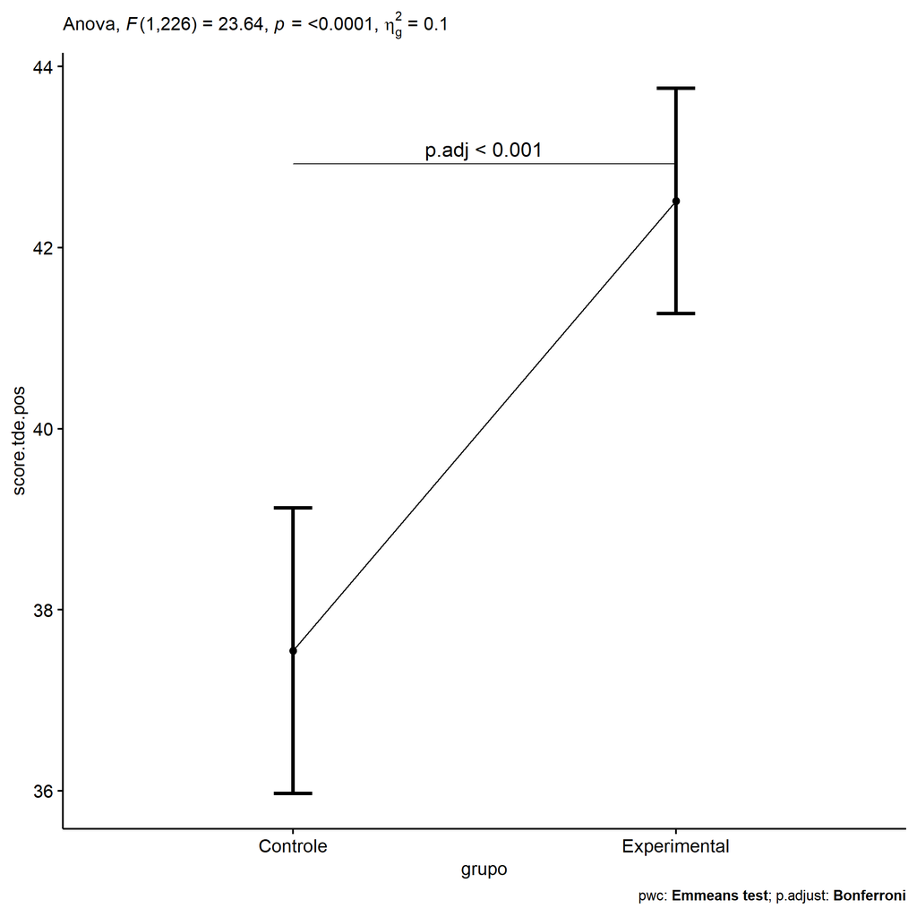

```r
if (!is.null(nrow(plots[["grupo"]]$data)))
  plots[["grupo"]] + ggplot2::scale_color_manual(values = color[["grupo"]])
```

```r
plots <- oneWayAncovaBoxPlots(
  wdat, "score.tde.pos", "grupo", aov, pwc, covar = "score.tde.pre",
  theme = "classic", color = color[["grupo"]],
  subtitle = which(aov$Effect == "grupo"))
```

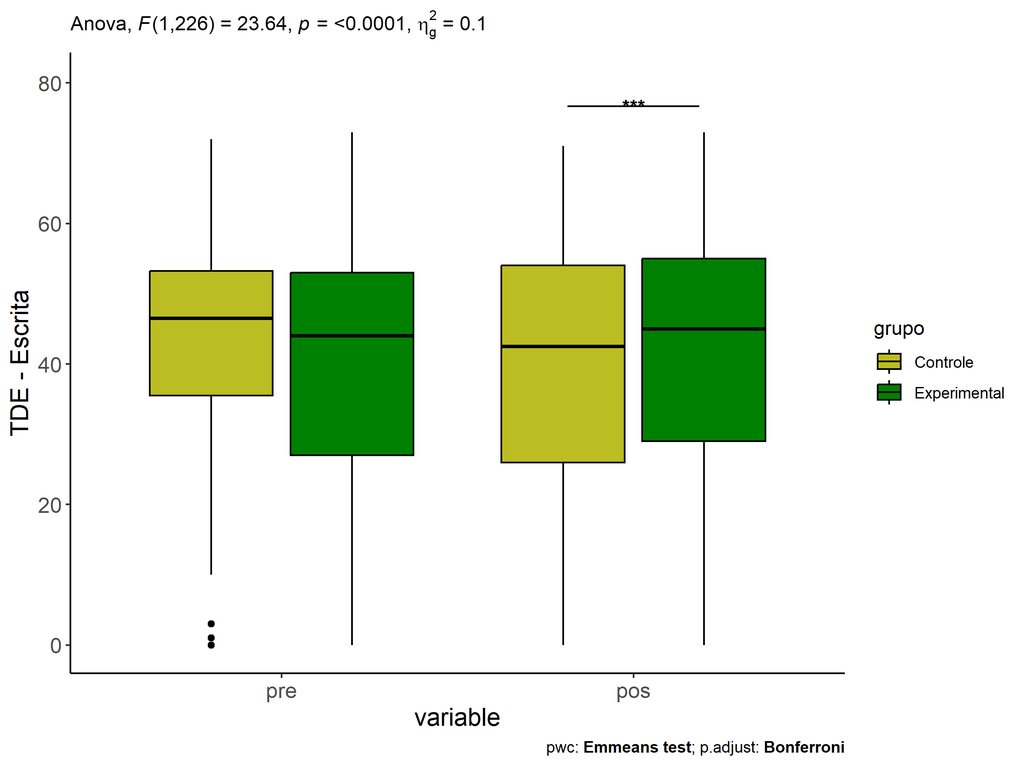

```r
if (length(unique(wdat[["grupo"]])) > 1)
  plots[["grupo"]] + ggplot2::ylab("TDE - Escrita") + ggplot2::scale_x_discrete(labels=c('pre', 'pos'))
```

```r
if (length(unique(wdat.long[["grupo"]])) > 1)
  plots <- oneWayAncovaBoxPlots(
    wdat.long, "score.tde", "grupo", aov, pwc.long, pre.post = "time",
    theme = "classic", color = color$prepost)
```

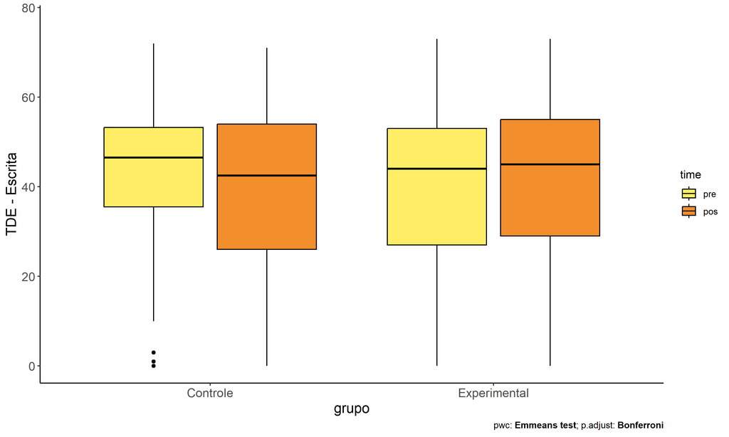

```r
if (length(unique(wdat.long[["grupo"]])) > 1)
  plots[["grupo"]] + ggplot2::ylab("TDE - Escrita")
```

### Checking linearity assumption

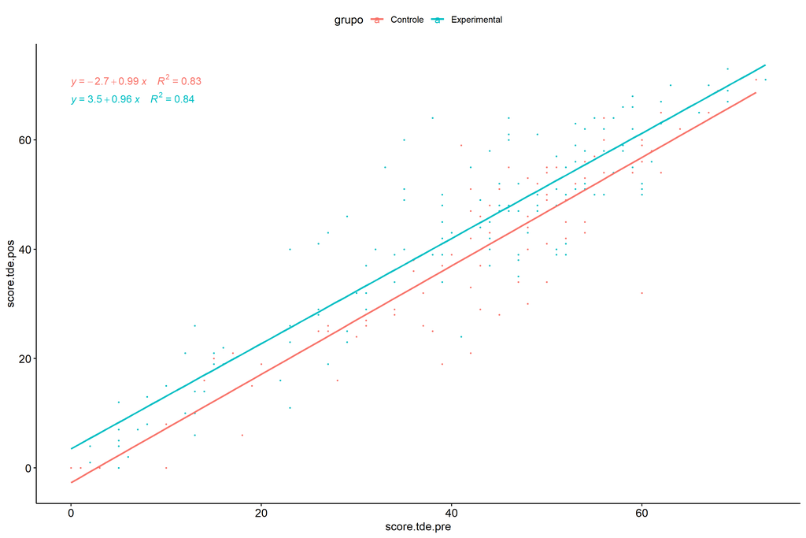

```r
ggscatter(wdat, x = "score.tde.pre", y = "score.tde.pos", size = 0.5,
          color = "grupo", add = "reg.line")+
  stat_regline_equation(
    aes(label =  paste(..eq.label.., ..rr.label.., sep = "~~~~"), color = grupo)
  )
```

### Checking normality and homogeneity

```r
res <- augment(lm(score.tde.pos ~ score.tde.pre + grupo, data = wdat))
```

```r
shapiro_test(res$.resid)
```

```
## # A tibble: 1 × 3
##   variable   statistic p.value
##   <chr>          <dbl>   <dbl>
## 1 res$.resid     0.989  0.0767
```

```r
levene_test(res, .resid ~ grupo)
```

```
## # A tibble: 1 × 4
##     df1   df2 statistic     p
##   <int> <int>     <dbl> <dbl>
## 1     1   227     0.344 0.558
```

# ANCOVA and Pairwise for two factors **grupo:Sexo**

## Without remove non-normal data

```r
pdat = remove_group_data(dat[!is.na(dat[["grupo"]]) & !is.na(dat[["Sexo"]]),], "score.tde.pos", c("grupo","Sexo"))

pdat.long <- rbind(pdat[,c("id","grupo","Sexo")], pdat[,c("id","grupo","Sexo")])
pdat.long[["time"]] <- c(rep("pre", nrow(pdat)), rep("pos", nrow(pdat)))
pdat.long[["time"]] <- factor(pdat.long[["time"]], c("pre","pos"))
pdat.long[["score.tde"]] <- c(pdat[["score.tde.pre"]], pdat[["score.tde.pos"]])

aov = anova_test(pdat, score.tde.pos ~ score.tde.pre + grupo*Sexo)
laov[["grupo:Sexo"]] <- get_anova_table(aov)
```

```r
pwcs <- list()
pwcs[["Sexo"]] <- emmeans_test(
  group_by(pdat, grupo), score.tde.pos ~ Sexo,
  covariate = score.tde.pre, p.adjust.method = "bonferroni")
pwcs[["grupo"]] <- emmeans_test(
  group_by(pdat, Sexo), score.tde.pos ~ grupo,
  covariate = score.tde.pre, p.adjust.method = "bonferroni")

pwc <- plyr::rbind.fill(pwcs[["grupo"]], pwcs[["Sexo"]])
pwc <- pwc[,c("grupo","Sexo", colnames(pwc)[!colnames(pwc) %in% c("grupo","Sexo")])]
```

```r
pwc.long <- emmeans_test(dplyr::group_by_at(pdat.long, c("grupo","Sexo")),
                         score.tde ~ time,
                         p.adjust.method = "bonferroni")
lpwc[["grupo:Sexo"]] <- plyr::rbind.fill(pwc, pwc.long)
```

```r
ds <- get.descriptives(pdat, "score.tde.pos", c("grupo","Sexo"), covar = "score.tde.pre")
ds <- merge(ds[ds$variable != "score.tde.pre",],
            ds[ds$variable == "score.tde.pre", !colnames(ds) %in% c("variable")],
            by = c("grupo","Sexo"), all.x = T, suffixes = c("", ".score.tde.pre"))
ds <- merge(get_emmeans(pwcs[["grupo"]]), ds, by = c("grupo","Sexo"), suffixes = c(".emms", ""))
ds <- ds[,c("grupo","Sexo","n","mean.score.tde.pre","se.score.tde.pre","mean","se","emmean","se.emms")]

colnames(ds) <- c("grupo","Sexo", "N", paste0(c("M","SE")," (pre)"),
                  paste0(c("M","SE"), " (unadj)"), paste0(c("M", "SE"), " (adj)"))

lemms[["grupo:Sexo"]] <- ds
```

## Computing ANCOVA and PairWise After removing non-normal data (OK)

```r
wdat = pdat

res = residuals(lm(score.tde.pos ~ score.tde.pre + grupo*Sexo, data = wdat))
non.normal = getNonNormal(res, wdat$id, plimit = 0.05)

wdat = wdat[!wdat$id %in% non.normal,]

wdat.long <- rbind(wdat[,c("id","grupo","Sexo")], wdat[,c("id","grupo","Sexo")])
wdat.long[["time"]] <- c(rep("pre", nrow(wdat)), rep("pos", nrow(wdat)))
wdat.long[["time"]] <- factor(wdat.long[["time"]], c("pre","pos"))
wdat.long[["score.tde"]] <- c(wdat[["score.tde.pre"]], wdat[["score.tde.pos"]])


ldat[["grupo:Sexo"]] = wdat

(non.normal)
```

```
## [1] "P3637"
```

```r
aov = anova_test(wdat, score.tde.pos ~ score.tde.pre + grupo*Sexo)
laov[["grupo:Sexo"]] <- merge(get_anova_table(aov), laov[["grupo:Sexo"]], by="Effect", suffixes = c("","'"))

(df = get_anova_table(aov))
```

```
## ANOVA Table (type II tests)
##
##          Effect DFn DFd        F        p p<.05     ges
## 1 score.tde.pre   1 226 1014.077 1.67e-85     * 0.81800
## 2         grupo   1 226   18.282 2.81e-05     * 0.07500
## 3          Sexo   1 226    4.841 2.90e-02     * 0.02100
## 4    grupo:Sexo   1 226    0.145 7.04e-01       0.00064
```

| Effect | DFn | DFd | F | p | p<.05 | ges |
| --- | --- | --- | --- | --- | --- | --- |
| score.tde.pre | 1 | 226 | 1014.077 | 0.000 | * | 0.818 |
| grupo | 1 | 226 | 18.282 | 0.000 | * | 0.075 |
| Sexo | 1 | 226 | 4.841 | 0.029 | * | 0.021 |
| grupo:Sexo | 1 | 226 | 0.145 | 0.704 |  | 0.001 |

```r
pwcs <- list()
pwcs[["Sexo"]] <- emmeans_test(
  group_by(wdat, grupo), score.tde.pos ~ Sexo,
  covariate = score.tde.pre, p.adjust.method = "bonferroni")
pwcs[["grupo"]] <- emmeans_test(
  group_by(wdat, Sexo), score.tde.pos ~ grupo,
  covariate = score.tde.pre, p.adjust.method = "bonferroni")

pwc <- plyr::rbind.fill(pwcs[["grupo"]], pwcs[["Sexo"]])
pwc <- pwc[,c("grupo","Sexo", colnames(pwc)[!colnames(pwc) %in% c("grupo","Sexo")])]
```

| grupo | Sexo | term | .y. | group1 | group2 | df | statistic | p | p.adj | p.adj.signif |
| --- | --- | --- | --- | --- | --- | --- | --- | --- | --- | --- |
|  | F | score.tde.pre*grupo | score.tde.pos | Controle | Experimental | 226 | -3.371 | 0.001 | 0.001 | *** |
|  | M | score.tde.pre*grupo | score.tde.pos | Controle | Experimental | 226 | -2.672 | 0.008 | 0.008 | ** |
| Controle |  | score.tde.pre*Sexo | score.tde.pos | F | M | 226 | 1.084 | 0.280 | 0.280 | ns |
| Experimental |  | score.tde.pre*Sexo | score.tde.pos | F | M | 226 | 1.973 | 0.050 | 0.050 | * |

```r
pwc.long <- emmeans_test(dplyr::group_by_at(wdat.long, c("grupo","Sexo")),
                         score.tde ~ time,
                         p.adjust.method = "bonferroni")
lpwc[["grupo:Sexo"]] <- merge(plyr::rbind.fill(pwc, pwc.long), lpwc[["grupo:Sexo"]], by=c("grupo","Sexo","term",".y.","group1","group2"), suffixes = c("","'"))
```

| grupo | Sexo | term | .y. | group1 | group2 | df | statistic | p | p.adj | p.adj.signif |
| --- | --- | --- | --- | --- | --- | --- | --- | --- | --- | --- |
| Controle | F | time | score.tde | pre | pos | 454 | 0.576 | 0.565 | 0.565 | ns |
| Controle | M | time | score.tde | pre | pos | 454 | 0.928 | 0.354 | 0.354 | ns |
| Experimental | F | time | score.tde | pre | pos | 454 | -1.001 | 0.317 | 0.317 | ns |
| Experimental | M | time | score.tde | pre | pos | 454 | -0.200 | 0.841 | 0.841 | ns |

```r
ds <- get.descriptives(wdat, "score.tde.pos", c("grupo","Sexo"), covar = "score.tde.pre")
ds <- merge(ds[ds$variable != "score.tde.pre",],
            ds[ds$variable == "score.tde.pre", !colnames(ds) %in% c("variable")],
            by = c("grupo","Sexo"), all.x = T, suffixes = c("", ".score.tde.pre"))
ds <- merge(get_emmeans(pwcs[["grupo"]]), ds, by = c("grupo","Sexo"), suffixes = c(".emms", ""))
ds <- ds[,c("grupo","Sexo","n","mean.score.tde.pre","se.score.tde.pre","mean","se","emmean","se.emms")]

colnames(ds) <- c("grupo","Sexo", "N", paste0(c("M","SE")," (pre)"),
                  paste0(c("M","SE"), " (unadj)"), paste0(c("M", "SE"), " (adj)"))

lemms[["grupo:Sexo"]] <- merge(ds, lemms[["grupo:Sexo"]], by=c("grupo","Sexo"), suffixes = c("","'"))
```

| grupo | Sexo | N | M (pre) | SE (pre) | M (unadj) | SE (unadj) | M (adj) | SE (adj) |
| --- | --- | --- | --- | --- | --- | --- | --- | --- |
| Controle | F | 48 | 45.771 | 2.184 | 43.688 | 2.435 | 38.607 | 1.139 |
| Controle | M | 41 | 38.854 | 2.682 | 35.220 | 2.841 | 36.793 | 1.221 |
| Experimental | F | 72 | 42.556 | 2.240 | 45.514 | 2.350 | 43.526 | 0.923 |
| Experimental | M | 70 | 35.700 | 1.969 | 36.300 | 2.079 | 40.906 | 0.945 |

### Plots for ancova

```r
plots <- twoWayAncovaPlots(
  wdat, "score.tde.pos", c("grupo","Sexo"), aov, pwcs, addParam = c("mean_se"),
  font.label.size=10, step.increase=0.05, p.label="p.adj",
  subtitle = which(aov$Effect == "grupo:Sexo"))
```

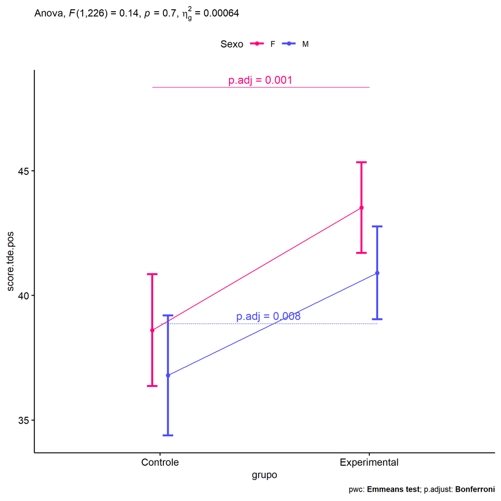

```r
if (!is.null(plots[["grupo"]]))
  plots[["grupo"]] + ggplot2::scale_color_manual(values = color[["Sexo"]])
```

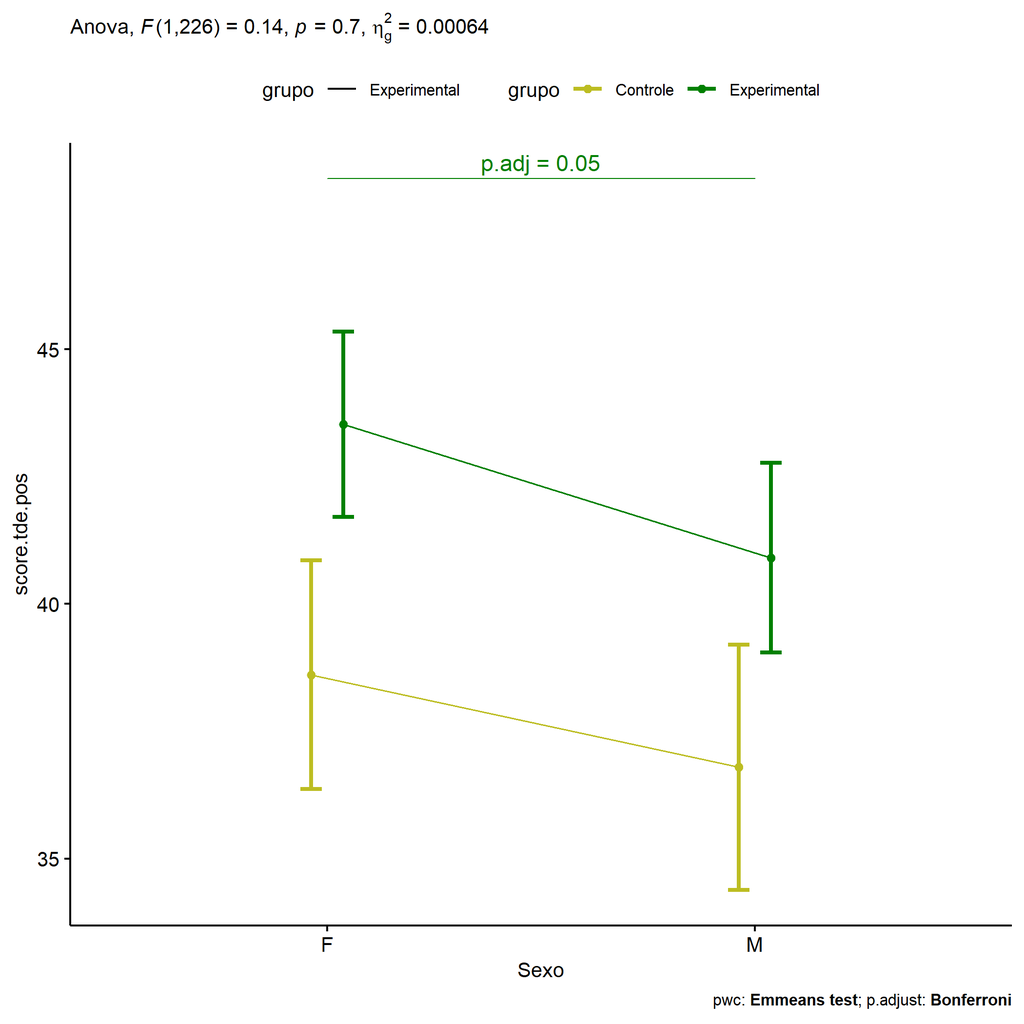

```r
if (!is.null(plots[["Sexo"]]))
  plots[["Sexo"]] + ggplot2::scale_color_manual(values = color[["grupo"]])
```

```r
plots <- twoWayAncovaBoxPlots(
  wdat, "score.tde.pos", c("grupo","Sexo"), aov, pwcs, covar = "score.tde.pre",
  theme = "classic", color = color[["grupo:Sexo"]],
  subtitle = which(aov$Effect == "grupo:Sexo"))
```

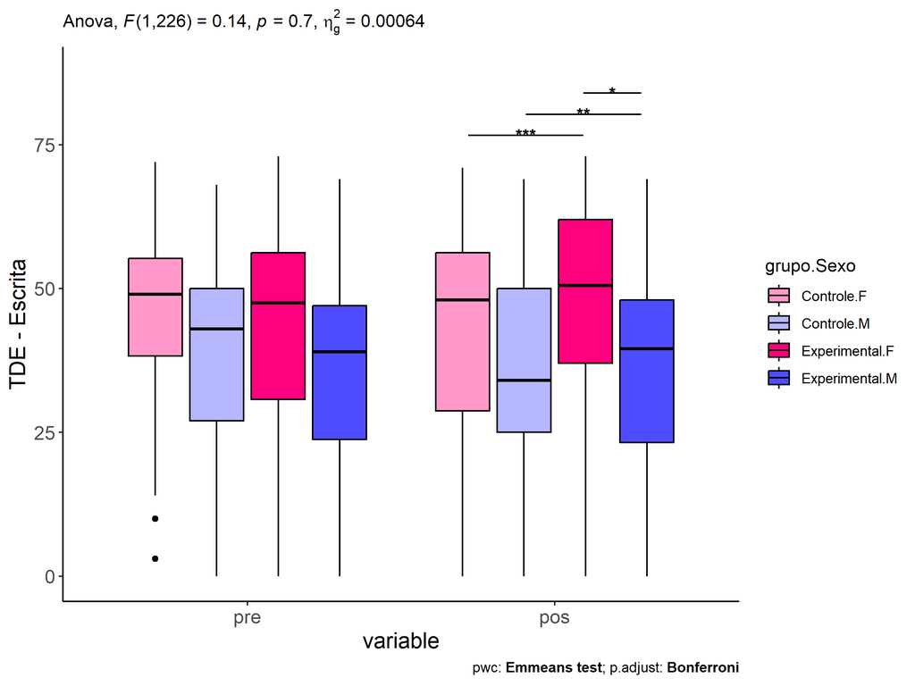

```r
plots[["grupo:Sexo"]] + ggplot2::ylab("TDE - Escrita") + ggplot2::scale_x_discrete(labels=c('pre', 'pos'))
```

```r
plots <- twoWayAncovaBoxPlots(
  wdat.long, "score.tde", c("grupo","Sexo"), aov, pwc.long, pre.post = "time",
  theme = "classic", color = color$prepost)
```

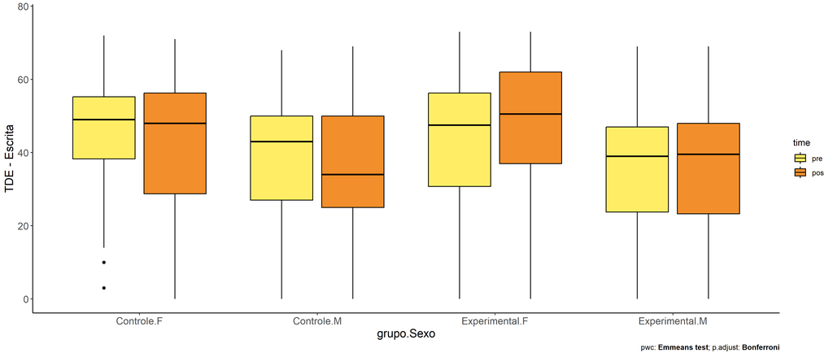

```r
plots[["grupo:Sexo"]] + ggplot2::ylab("TDE - Escrita")
```

### Checking linearity assumption

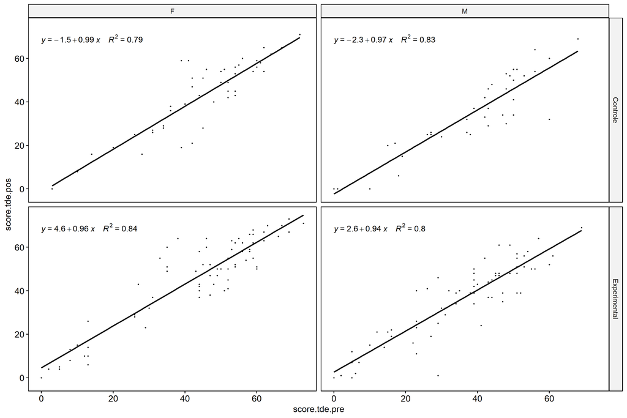

```r
ggscatter(wdat, x = "score.tde.pre", y = "score.tde.pos", size = 0.5,
          facet.by = c("grupo","Sexo"), add = "reg.line")+
  stat_regline_equation(
    aes(label =  paste(..eq.label.., ..rr.label.., sep = "~~~~"))
  )
```

### Checking normality and homogeneity

```r
res <- augment(lm(score.tde.pos ~ score.tde.pre + grupo*Sexo, data = wdat))
```

```r
shapiro_test(res$.resid)
```

```
## # A tibble: 1 × 3
##   variable   statistic p.value
##   <chr>          <dbl>   <dbl>
## 1 res$.resid     0.986  0.0250
```

```r
levene_test(res, .resid ~ grupo*Sexo)
```

```
## # A tibble: 1 × 4
##     df1   df2 statistic     p
##   <int> <int>     <dbl> <dbl>
## 1     3   227     0.153 0.928
```

# ANCOVA and Pairwise for two factors **grupo:Zona**

## Without remove non-normal data

```r
pdat = remove_group_data(dat[!is.na(dat[["grupo"]]) & !is.na(dat[["Zona"]]),], "score.tde.pos", c("grupo","Zona"))

pdat.long <- rbind(pdat[,c("id","grupo","Zona")], pdat[,c("id","grupo","Zona")])
pdat.long[["time"]] <- c(rep("pre", nrow(pdat)), rep("pos", nrow(pdat)))
pdat.long[["time"]] <- factor(pdat.long[["time"]], c("pre","pos"))
pdat.long[["score.tde"]] <- c(pdat[["score.tde.pre"]], pdat[["score.tde.pos"]])

aov = anova_test(pdat, score.tde.pos ~ score.tde.pre + grupo*Zona)
laov[["grupo:Zona"]] <- get_anova_table(aov)
```

```r
pwcs <- list()
pwcs[["Zona"]] <- emmeans_test(
  group_by(pdat, grupo), score.tde.pos ~ Zona,
  covariate = score.tde.pre, p.adjust.method = "bonferroni")
pwcs[["grupo"]] <- emmeans_test(
  group_by(pdat, Zona), score.tde.pos ~ grupo,
  covariate = score.tde.pre, p.adjust.method = "bonferroni")

pwc <- plyr::rbind.fill(pwcs[["grupo"]], pwcs[["Zona"]])
pwc <- pwc[,c("grupo","Zona", colnames(pwc)[!colnames(pwc) %in% c("grupo","Zona")])]
```

```r
pwc.long <- emmeans_test(dplyr::group_by_at(pdat.long, c("grupo","Zona")),
                         score.tde ~ time,
                         p.adjust.method = "bonferroni")
lpwc[["grupo:Zona"]] <- plyr::rbind.fill(pwc, pwc.long)
```

```r
ds <- get.descriptives(pdat, "score.tde.pos", c("grupo","Zona"), covar = "score.tde.pre")
ds <- merge(ds[ds$variable != "score.tde.pre",],
            ds[ds$variable == "score.tde.pre", !colnames(ds) %in% c("variable")],
            by = c("grupo","Zona"), all.x = T, suffixes = c("", ".score.tde.pre"))
ds <- merge(get_emmeans(pwcs[["grupo"]]), ds, by = c("grupo","Zona"), suffixes = c(".emms", ""))
ds <- ds[,c("grupo","Zona","n","mean.score.tde.pre","se.score.tde.pre","mean","se","emmean","se.emms")]

colnames(ds) <- c("grupo","Zona", "N", paste0(c("M","SE")," (pre)"),
                  paste0(c("M","SE"), " (unadj)"), paste0(c("M", "SE"), " (adj)"))

lemms[["grupo:Zona"]] <- ds
```

## Computing ANCOVA and PairWise After removing non-normal data (OK)

```r
wdat = pdat

res = residuals(lm(score.tde.pos ~ score.tde.pre + grupo*Zona, data = wdat))
non.normal = getNonNormal(res, wdat$id, plimit = 0.05)

wdat = wdat[!wdat$id %in% non.normal,]

wdat.long <- rbind(wdat[,c("id","grupo","Zona")], wdat[,c("id","grupo","Zona")])
wdat.long[["time"]] <- c(rep("pre", nrow(wdat)), rep("pos", nrow(wdat)))
wdat.long[["time"]] <- factor(wdat.long[["time"]], c("pre","pos"))
wdat.long[["score.tde"]] <- c(wdat[["score.tde.pre"]], wdat[["score.tde.pos"]])


ldat[["grupo:Zona"]] = wdat

(non.normal)
```

```
## [1] "P572"  "P1018" "P3660"
```

```r
aov = anova_test(wdat, score.tde.pos ~ score.tde.pre + grupo*Zona)
laov[["grupo:Zona"]] <- merge(get_anova_table(aov), laov[["grupo:Zona"]], by="Effect", suffixes = c("","'"))

(df = get_anova_table(aov))
```

```
## ANOVA Table (type II tests)
##
##          Effect DFn DFd       F        p p<.05      ges
## 1 score.tde.pre   1 117 718.826 8.79e-52     * 0.860000
## 2         grupo   1 117   6.605 1.10e-02     * 0.053000
## 3          Zona   1 117   0.057 8.12e-01       0.000483
## 4    grupo:Zona   1 117   1.559 2.14e-01       0.013000
```

| Effect | DFn | DFd | F | p | p<.05 | ges |
| --- | --- | --- | --- | --- | --- | --- |
| score.tde.pre | 1 | 117 | 718.826 | 0.000 | * | 0.860 |
| grupo | 1 | 117 | 6.605 | 0.011 | * | 0.053 |
| Zona | 1 | 117 | 0.057 | 0.812 |  | 0.000 |
| grupo:Zona | 1 | 117 | 1.559 | 0.214 |  | 0.013 |

```r
pwcs <- list()
pwcs[["Zona"]] <- emmeans_test(
  group_by(wdat, grupo), score.tde.pos ~ Zona,
  covariate = score.tde.pre, p.adjust.method = "bonferroni")
pwcs[["grupo"]] <- emmeans_test(
  group_by(wdat, Zona), score.tde.pos ~ grupo,
  covariate = score.tde.pre, p.adjust.method = "bonferroni")

pwc <- plyr::rbind.fill(pwcs[["grupo"]], pwcs[["Zona"]])
pwc <- pwc[,c("grupo","Zona", colnames(pwc)[!colnames(pwc) %in% c("grupo","Zona")])]
```

| grupo | Zona | term | .y. | group1 | group2 | df | statistic | p | p.adj | p.adj.signif |
| --- | --- | --- | --- | --- | --- | --- | --- | --- | --- | --- |
|  | Rural | score.tde.pre*grupo | score.tde.pos | Controle | Experimental | 117 | -1.373 | 0.172 | 0.172 | ns |
|  | Urbana | score.tde.pre*grupo | score.tde.pos | Controle | Experimental | 117 | -2.507 | 0.014 | 0.014 | * |
| Controle |  | score.tde.pre*Zona | score.tde.pos | Rural | Urbana | 117 | 1.094 | 0.276 | 0.276 | ns |
| Experimental |  | score.tde.pre*Zona | score.tde.pos | Rural | Urbana | 117 | -0.643 | 0.522 | 0.522 | ns |

```r
pwc.long <- emmeans_test(dplyr::group_by_at(wdat.long, c("grupo","Zona")),
                         score.tde ~ time,
                         p.adjust.method = "bonferroni")
lpwc[["grupo:Zona"]] <- merge(plyr::rbind.fill(pwc, pwc.long), lpwc[["grupo:Zona"]], by=c("grupo","Zona","term",".y.","group1","group2"), suffixes = c("","'"))
```

| grupo | Zona | term | .y. | group1 | group2 | df | statistic | p | p.adj | p.adj.signif |
| --- | --- | --- | --- | --- | --- | --- | --- | --- | --- | --- |
| Controle | Rural | time | score.tde | pre | pos | 236 | 0.288 | 0.774 | 0.774 | ns |
| Controle | Urbana | time | score.tde | pre | pos | 236 | 0.599 | 0.550 | 0.550 | ns |
| Experimental | Rural | time | score.tde | pre | pos | 236 | -0.255 | 0.799 | 0.799 | ns |
| Experimental | Urbana | time | score.tde | pre | pos | 236 | -0.367 | 0.714 | 0.714 | ns |

```r
ds <- get.descriptives(wdat, "score.tde.pos", c("grupo","Zona"), covar = "score.tde.pre")
ds <- merge(ds[ds$variable != "score.tde.pre",],
            ds[ds$variable == "score.tde.pre", !colnames(ds) %in% c("variable")],
            by = c("grupo","Zona"), all.x = T, suffixes = c("", ".score.tde.pre"))
ds <- merge(get_emmeans(pwcs[["grupo"]]), ds, by = c("grupo","Zona"), suffixes = c(".emms", ""))
ds <- ds[,c("grupo","Zona","n","mean.score.tde.pre","se.score.tde.pre","mean","se","emmean","se.emms")]

colnames(ds) <- c("grupo","Zona", "N", paste0(c("M","SE")," (pre)"),
                  paste0(c("M","SE"), " (unadj)"), paste0(c("M", "SE"), " (adj)"))

lemms[["grupo:Zona"]] <- merge(ds, lemms[["grupo:Zona"]], by=c("grupo","Zona"), suffixes = c("","'"))
```

| grupo | Zona | N | M (pre) | SE (pre) | M (unadj) | SE (unadj) | M (adj) | SE (adj) |
| --- | --- | --- | --- | --- | --- | --- | --- | --- |
| Controle | Rural | 31 | 43.387 | 3.098 | 42.065 | 3.385 | 40.644 | 1.263 |
| Controle | Urbana | 18 | 45.333 | 3.881 | 41.722 | 4.095 | 38.366 | 1.660 |
| Experimental | Rural | 52 | 38.769 | 2.596 | 39.673 | 2.805 | 42.846 | 0.981 |
| Experimental | Urbana | 21 | 44.857 | 3.255 | 46.905 | 3.309 | 44.022 | 1.537 |

### Plots for ancova

```r
plots <- twoWayAncovaPlots(
  wdat, "score.tde.pos", c("grupo","Zona"), aov, pwcs, addParam = c("mean_se"),
  font.label.size=10, step.increase=0.05, p.label="p.adj",
  subtitle = which(aov$Effect == "grupo:Zona"))
```

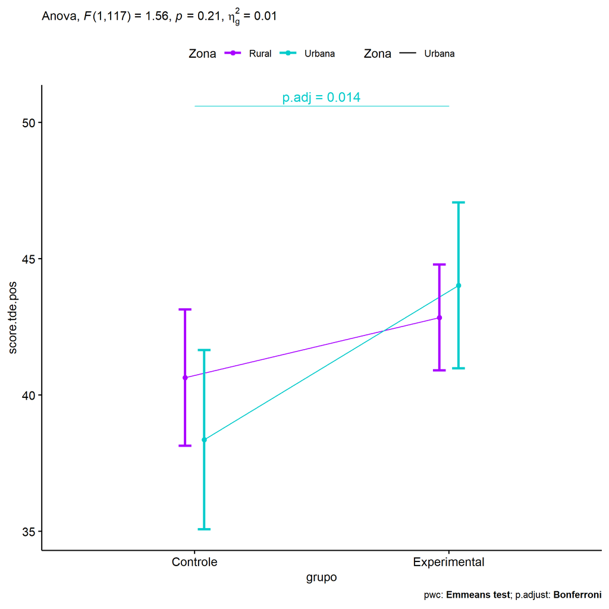

```r
if (!is.null(plots[["grupo"]]))
  plots[["grupo"]] + ggplot2::scale_color_manual(values = color[["Zona"]])
```

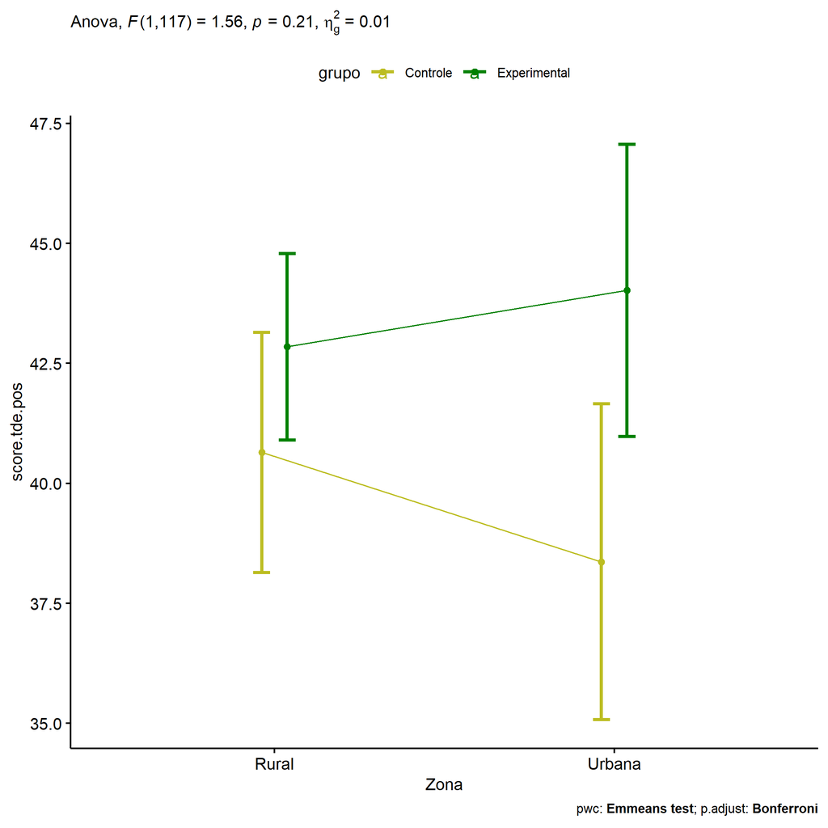

```r
if (!is.null(plots[["Zona"]]))
  plots[["Zona"]] + ggplot2::scale_color_manual(values = color[["grupo"]])
```

```r
plots <- twoWayAncovaBoxPlots(
  wdat, "score.tde.pos", c("grupo","Zona"), aov, pwcs, covar = "score.tde.pre",
  theme = "classic", color = color[["grupo:Zona"]],
  subtitle = which(aov$Effect == "grupo:Zona"))
```

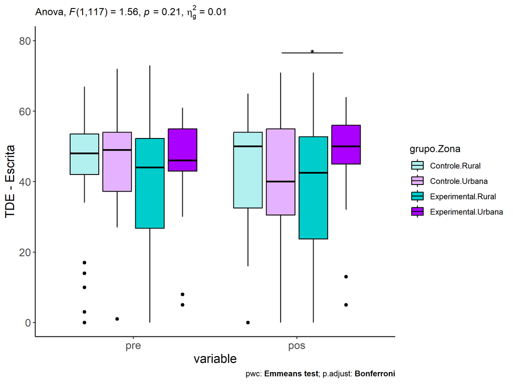

```r
plots[["grupo:Zona"]] + ggplot2::ylab("TDE - Escrita") + ggplot2::scale_x_discrete(labels=c('pre', 'pos'))
```

```r
plots <- twoWayAncovaBoxPlots(
  wdat.long, "score.tde", c("grupo","Zona"), aov, pwc.long, pre.post = "time",
  theme = "classic", color = color$prepost)
```

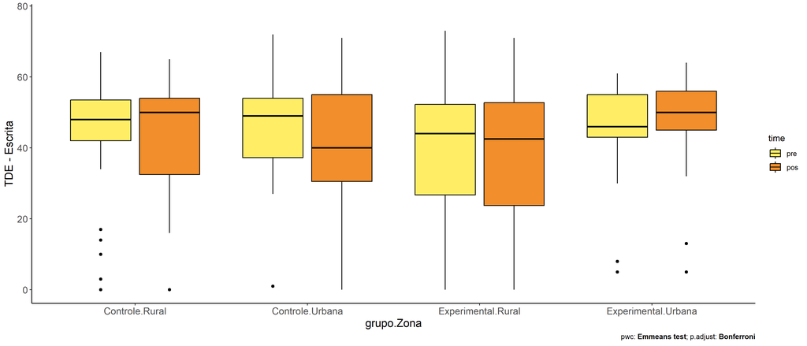

```r
plots[["grupo:Zona"]] + ggplot2::ylab("TDE - Escrita")
```

### Checking linearity assumption

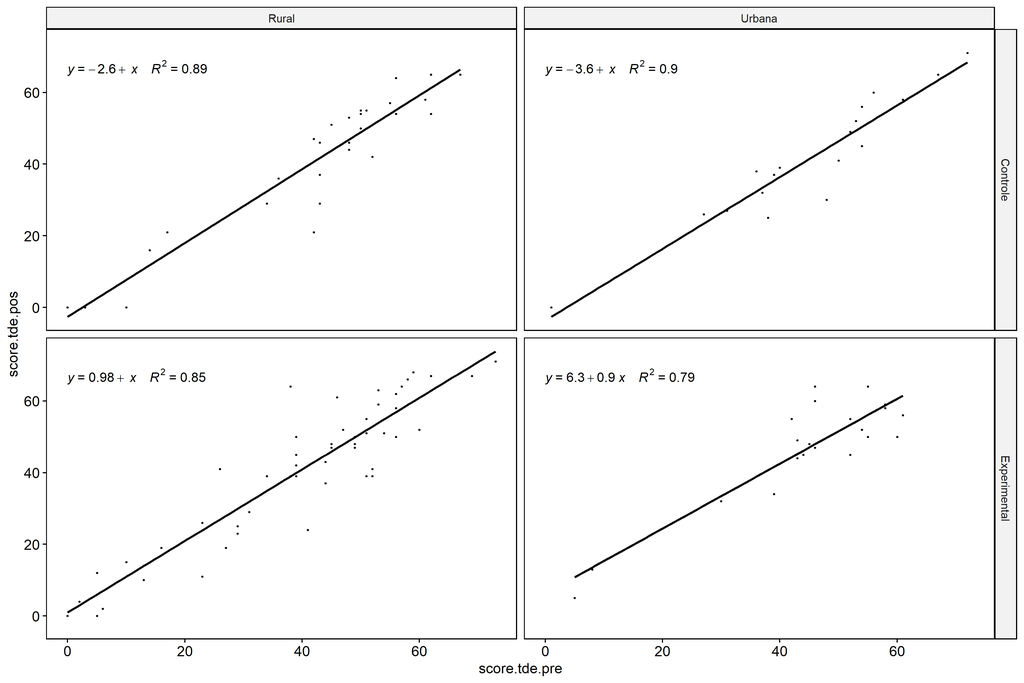

```r
ggscatter(wdat, x = "score.tde.pre", y = "score.tde.pos", size = 0.5,
          facet.by = c("grupo","Zona"), add = "reg.line")+
  stat_regline_equation(
    aes(label =  paste(..eq.label.., ..rr.label.., sep = "~~~~"))
  )
```

### Checking normality and homogeneity

```r
res <- augment(lm(score.tde.pos ~ score.tde.pre + grupo*Zona, data = wdat))
```

```r
shapiro_test(res$.resid)
```

```
## # A tibble: 1 × 3
##   variable   statistic p.value
##   <chr>          <dbl>   <dbl>
## 1 res$.resid     0.980  0.0604
```

```r
levene_test(res, .resid ~ grupo*Zona)
```

```
## # A tibble: 1 × 4
##     df1   df2 statistic     p
##   <int> <int>     <dbl> <dbl>
## 1     3   118     0.966 0.411
```

# ANCOVA and Pairwise for two factors **grupo:Cor.Raca**

## Without remove non-normal data

```r
pdat = remove_group_data(dat[!is.na(dat[["grupo"]]) & !is.na(dat[["Cor.Raca"]]),], "score.tde.pos", c("grupo","Cor.Raca"))
pdat.long <- rbind(pdat[,c("id","grupo","Cor.Raca")], pdat[,c("id","grupo","Cor.Raca")])
pdat.long[["time"]] <- c(rep("pre", nrow(pdat)), rep("pos", nrow(pdat)))
pdat.long[["time"]] <- factor(pdat.long[["time"]], c("pre","pos"))
pdat.long[["score.tde"]] <- c(pdat[["score.tde.pre"]], pdat[["score.tde.pos"]])

aov = anova_test(pdat, score.tde.pos ~ score.tde.pre + grupo*Cor.Raca)
laov[["grupo:Cor.Raca"]] <- get_anova_table(aov)
```

```r
pwcs <- list()
pwcs[["Cor.Raca"]] <- emmeans_test(
  group_by(pdat, grupo), score.tde.pos ~ Cor.Raca,
  covariate = score.tde.pre, p.adjust.method = "bonferroni")
pwcs[["grupo"]] <- emmeans_test(
  group_by(pdat, Cor.Raca), score.tde.pos ~ grupo,
  covariate = score.tde.pre, p.adjust.method = "bonferroni")

pwc <- plyr::rbind.fill(pwcs[["grupo"]], pwcs[["Cor.Raca"]])
pwc <- pwc[,c("grupo","Cor.Raca", colnames(pwc)[!colnames(pwc) %in% c("grupo","Cor.Raca")])]
```

```r
pwc.long <- emmeans_test(dplyr::group_by_at(pdat.long, c("grupo","Cor.Raca")),
                         score.tde ~ time,
                         p.adjust.method = "bonferroni")
lpwc[["grupo:Cor.Raca"]] <- plyr::rbind.fill(pwc, pwc.long)
```

```r
ds <- get.descriptives(pdat, "score.tde.pos", c("grupo","Cor.Raca"), covar = "score.tde.pre")
ds <- merge(ds[ds$variable != "score.tde.pre",],
            ds[ds$variable == "score.tde.pre", !colnames(ds) %in% c("variable")],
            by = c("grupo","Cor.Raca"), all.x = T, suffixes = c("", ".score.tde.pre"))
ds <- merge(get_emmeans(pwcs[["grupo"]]), ds, by = c("grupo","Cor.Raca"), suffixes = c(".emms", ""))
ds <- ds[,c("grupo","Cor.Raca","n","mean.score.tde.pre","se.score.tde.pre","mean","se","emmean","se.emms")]

colnames(ds) <- c("grupo","Cor.Raca", "N", paste0(c("M","SE")," (pre)"),
                  paste0(c("M","SE"), " (unadj)"), paste0(c("M", "SE"), " (adj)"))

lemms[["grupo:Cor.Raca"]] <- ds
```

## Computing ANCOVA and PairWise After removing non-normal data (OK)

```r
wdat = pdat

res = residuals(lm(score.tde.pos ~ score.tde.pre + grupo*Cor.Raca, data = wdat))
non.normal = getNonNormal(res, wdat$id, plimit = 0.05)

wdat = wdat[!wdat$id %in% non.normal,]

wdat.long <- rbind(wdat[,c("id","grupo","Cor.Raca")], wdat[,c("id","grupo","Cor.Raca")])
wdat.long[["time"]] <- c(rep("pre", nrow(wdat)), rep("pos", nrow(wdat)))
wdat.long[["time"]] <- factor(wdat.long[["time"]], c("pre","pos"))
wdat.long[["score.tde"]] <- c(wdat[["score.tde.pre"]], wdat[["score.tde.pos"]])


ldat[["grupo:Cor.Raca"]] = wdat

(non.normal)
```

```
## [1] "P3637"
```

```r
aov = anova_test(wdat, score.tde.pos ~ score.tde.pre + grupo*Cor.Raca)
laov[["grupo:Cor.Raca"]] <- merge(get_anova_table(aov), laov[["grupo:Cor.Raca"]], by="Effect", suffixes = c("","'"))

(df = get_anova_table(aov))
```

```
## ANOVA Table (type II tests)
##
##           Effect DFn DFd       F        p p<.05   ges
## 1  score.tde.pre   1 100 369.538 2.33e-35     * 0.787
## 2          grupo   1 100   5.196 2.50e-02     * 0.049
## 3       Cor.Raca   1 100   2.822 9.60e-02       0.027
## 4 grupo:Cor.Raca   0 100      NA       NA  <NA>    NA
```

| Effect | DFn | DFd | F | p | p<.05 | ges |
| --- | --- | --- | --- | --- | --- | --- |
| score.tde.pre | 1 | 100 | 369.538 | 0.000 | * | 0.787 |
| grupo | 1 | 100 | 5.196 | 0.025 | * | 0.049 |
| Cor.Raca | 1 | 100 | 2.822 | 0.096 |  | 0.027 |
| grupo:Cor.Raca | 0 | 100 |  |  |  |  |

```r
pwcs <- list()
pwcs[["Cor.Raca"]] <- emmeans_test(
  group_by(wdat, grupo), score.tde.pos ~ Cor.Raca,
  covariate = score.tde.pre, p.adjust.method = "bonferroni")
pwcs[["grupo"]] <- emmeans_test(
  group_by(wdat, Cor.Raca), score.tde.pos ~ grupo,
  covariate = score.tde.pre, p.adjust.method = "bonferroni")

pwc <- plyr::rbind.fill(pwcs[["grupo"]], pwcs[["Cor.Raca"]])
pwc <- pwc[,c("grupo","Cor.Raca", colnames(pwc)[!colnames(pwc) %in% c("grupo","Cor.Raca")])]
```

| grupo | Cor.Raca | term | .y. | group1 | group2 | df | statistic | p | p.adj | p.adj.signif |
| --- | --- | --- | --- | --- | --- | --- | --- | --- | --- | --- |
|  | Branca | score.tde.pre*grupo | score.tde.pos | Controle | Experimental |  |  |  |  |  |
|  | Parda | score.tde.pre*grupo | score.tde.pos | Controle | Experimental | 100 | -2.279 | 0.025 | 0.025 | * |
| Controle |  | score.tde.pre*Cor.Raca | score.tde.pos | Branca | Parda |  |  |  |  |  |
| Experimental |  | score.tde.pre*Cor.Raca | score.tde.pos | Branca | Parda | 100 | -1.680 | 0.096 | 0.096 | ns |

```r
pwc.long <- emmeans_test(dplyr::group_by_at(wdat.long, c("grupo","Cor.Raca")),
                         score.tde ~ time,
                         p.adjust.method = "bonferroni")
lpwc[["grupo:Cor.Raca"]] <- merge(plyr::rbind.fill(pwc, pwc.long), lpwc[["grupo:Cor.Raca"]], by=c("grupo","Cor.Raca","term",".y.","group1","group2"), suffixes = c("","'"))
```

| grupo | Cor.Raca | term | .y. | group1 | group2 | df | statistic | p | p.adj | p.adj.signif |
| --- | --- | --- | --- | --- | --- | --- | --- | --- | --- | --- |
| Controle | Branca | time | score.tde | pre | pos |  |  |  |  |  |
| Controle | Parda | time | score.tde | pre | pos | 202 | 0.655 | 0.513 | 0.513 | ns |
| Experimental | Branca | time | score.tde | pre | pos | 202 | 0.390 | 0.697 | 0.697 | ns |
| Experimental | Parda | time | score.tde | pre | pos | 202 | -0.482 | 0.630 | 0.630 | ns |

```r
ds <- get.descriptives(wdat, "score.tde.pos", c("grupo","Cor.Raca"), covar = "score.tde.pre")
ds <- merge(ds[ds$variable != "score.tde.pre",],
            ds[ds$variable == "score.tde.pre", !colnames(ds) %in% c("variable")],
            by = c("grupo","Cor.Raca"), all.x = T, suffixes = c("", ".score.tde.pre"))
ds <- merge(get_emmeans(pwcs[["grupo"]]), ds, by = c("grupo","Cor.Raca"), suffixes = c(".emms", ""))
ds <- ds[,c("grupo","Cor.Raca","n","mean.score.tde.pre","se.score.tde.pre","mean","se","emmean","se.emms")]

colnames(ds) <- c("grupo","Cor.Raca", "N", paste0(c("M","SE")," (pre)"),
                  paste0(c("M","SE"), " (unadj)"), paste0(c("M", "SE"), " (adj)"))

lemms[["grupo:Cor.Raca"]] <- merge(ds, lemms[["grupo:Cor.Raca"]], by=c("grupo","Cor.Raca"), suffixes = c("","'"))
```

| grupo | Cor.Raca | N | M (pre) | SE (pre) | M (unadj) | SE (unadj) | M (adj) | SE (adj) |
| --- | --- | --- | --- | --- | --- | --- | --- | --- |
| Controle | Parda | 34 | 44.353 | 2.535 | 41.324 | 3.133 | 37.156 | 1.612 |
| Experimental | Branca | 20 | 40.800 | 4.718 | 38.450 | 5.346 | 37.801 | 2.083 |
| Experimental | Parda | 50 | 37.020 | 2.637 | 38.860 | 2.775 | 41.954 | 1.327 |